I apply topic model to various gene expression datasets, and show the distribution of p values.

# Datasets:

They are all stored at "/project/mstephens/zihao/count_dataset/".

## - GTEx

- processed by Peter Carbonetto. See his process in "/project2/mstephens/pcarbo/git/topics/docs/prepare_gtex.html".
- It is first downloaded as "GTEx_Analysis_2016-01-15_v7_RNASeQCv1.1.8_gene_reads.gct.gz"
- I further divide the big data into 30 subtypes by tissue names. Below I will show the result for "brain"

## - 10xgenomics

- processed by Abhishek Sarkar.
- data is from https://www.nature.com/articles/ncomms14049
- I will show the result for "fresh_68k_pbmc_donor_a"

# Experiment setup

- generate training and validation dataset by $X_{\text{train}} \sim Binomial(X, 0.5)$ \begin{align} X_{\text{train}} & \sim Binomial(X, 0.5)\\ X_{\text{valid}} & = X - X_{\text{train}} \end{align}
- I fit the models described below, then computed the pvalue

# Model

## - General Model

\begin{align} X_{ij} & \sim Pois(\Lambda_{ij})\\ \Lambda & \sim f(\phi(\sum_k l_{ik} f_{jk})) \end{align} where $\phi$ is a deterministic function, and $f$ is a distribution.

## - NMF

I start off with NMF, which has $\Lambda = \sum_k l_{ik} f_{jk}$

# GTEx (brain)

## - What the data looks like

### Heatmap

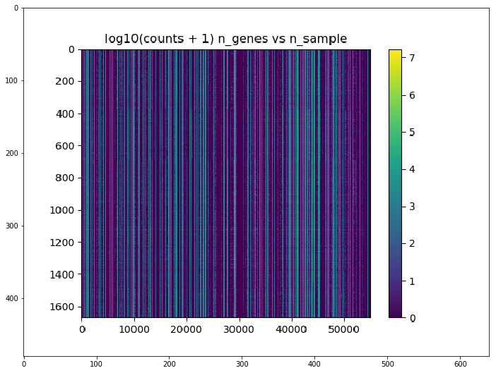

### Histogram

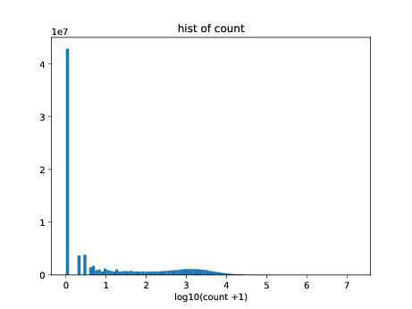

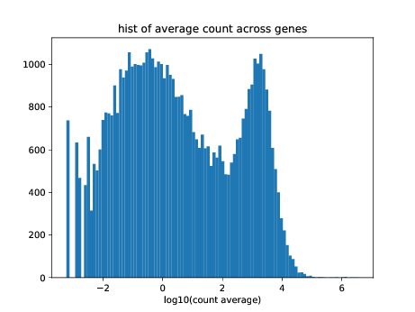

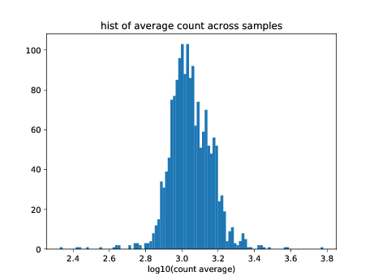

## - P values

### p-value (method: NMF_KL)

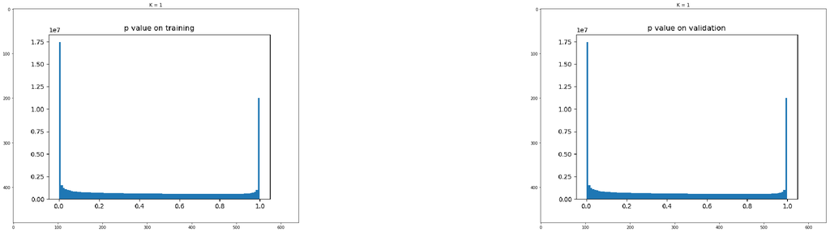

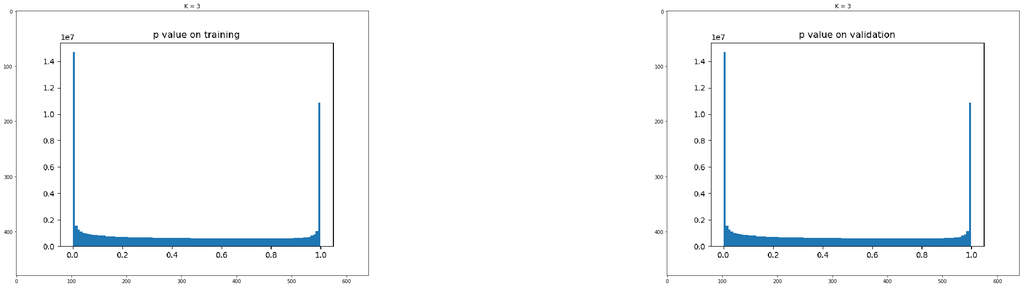

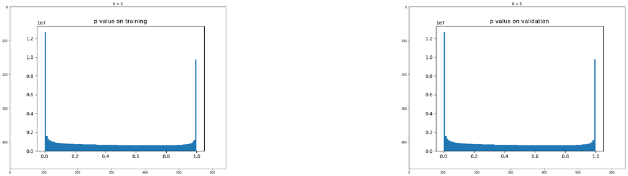

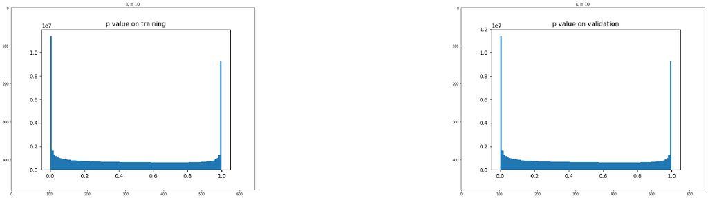

### p-value (method: NMF_l2 on log transformed data)

\begin{align} Y &= log(X + 1)\\ L,F &<- NMFl2(Y,K)\\ pval &<- pvalue(X, exp(LF' - 1)) \end{align}

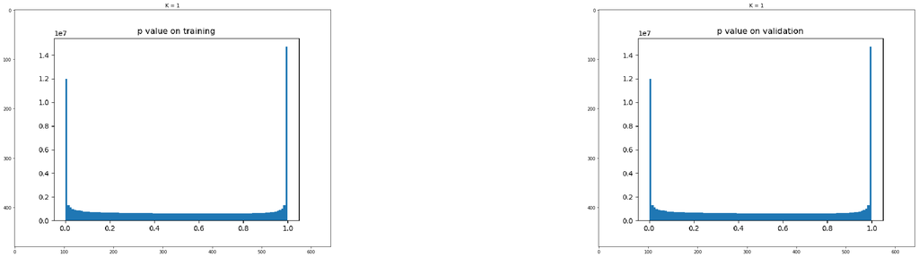

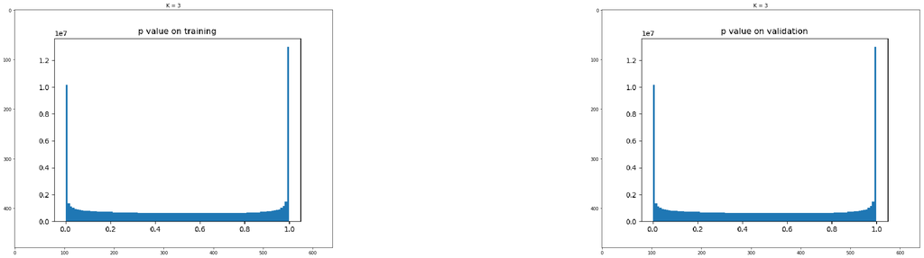

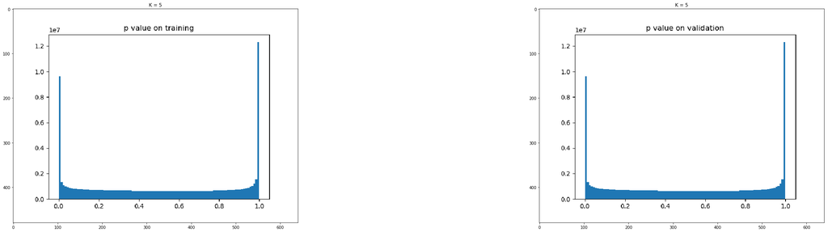

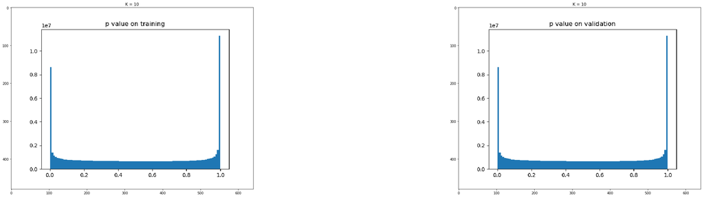

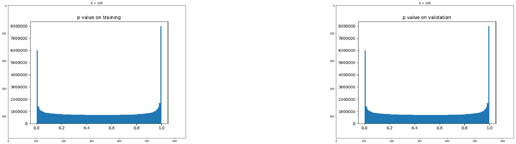

# 10xgenomics (fresh_68k_pbmc_donor_a)

## - What the data looks like

### Heatmap

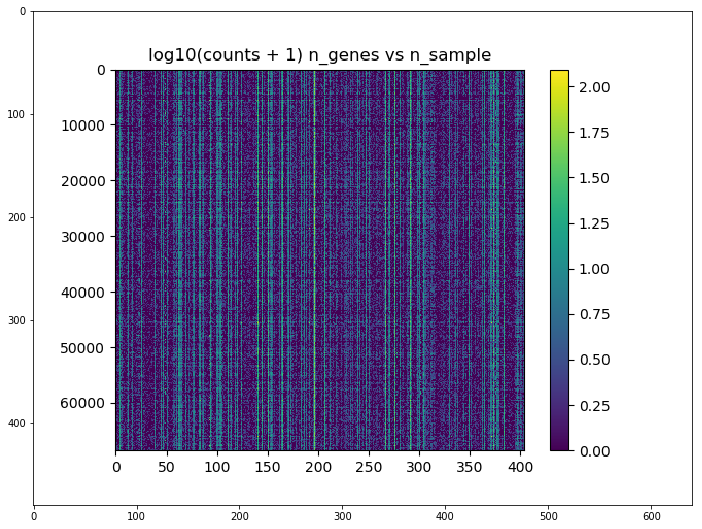

## Histogram

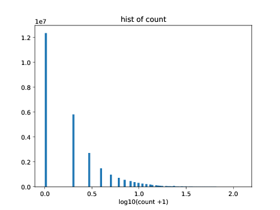

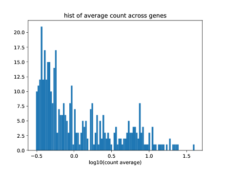

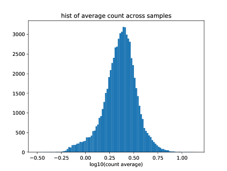

## P values

### p-value (method: NMF_KL)

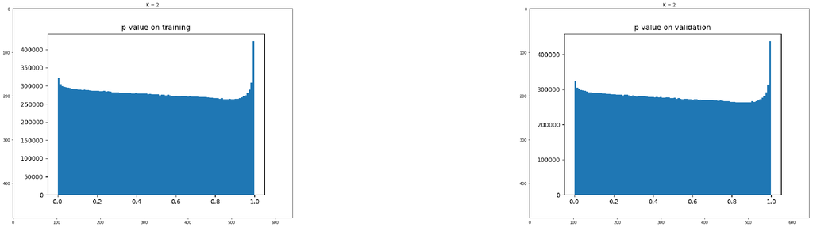

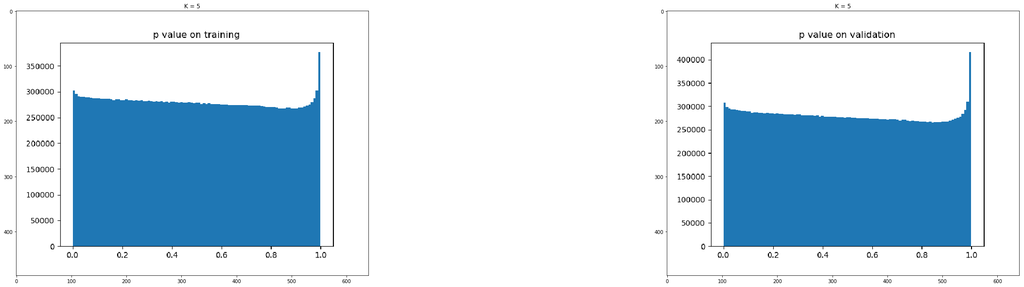

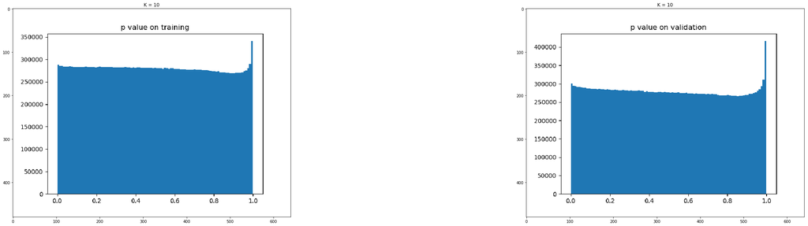

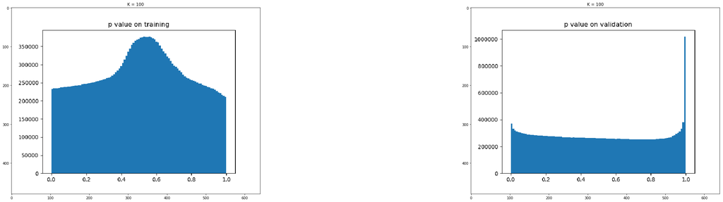

### p-value (method: NMF_l2 on log transformed data)

\begin{align} Y &= log(X + 1)\\ L,F &<- NMFl2(Y,K)\\ pval &<- pvalue(X, exp(LF' - 1)) \end{align}

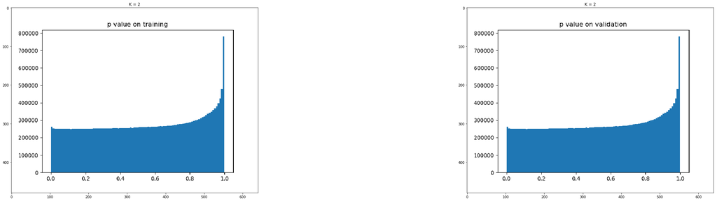

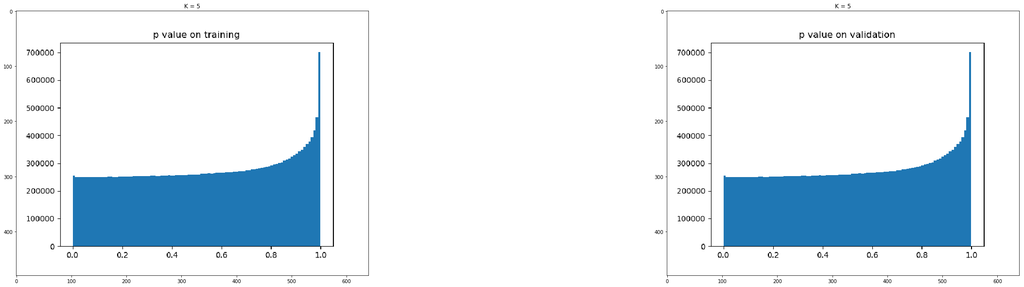

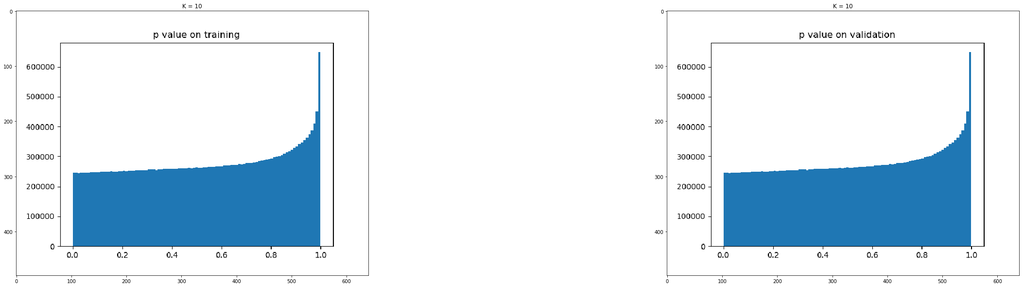

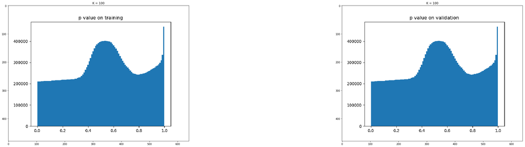

Technical tips:

- Displaying embedded images when converting ipynb to html, use the extension below. https://jupyter-contrib-nbextensions.readthedocs.io/en/latest/install.html
- Installing packages to Anaconda in midway2:

  ```
  # import sys
  # !{sys.executable} -m pip install --user wand
  ```